# Bank_Personal_Loan_Modelling_Project_Delivery_Makarand_More_main

### Project - Bank_Personal_Loan_Modelling

```python
#Student Name : Makarand More
```

```python
#Task 1: Import the datasets and libraries, check datatype, statistical summary, shape, null values or
#incorrect imputation.

import warnings
warnings.filterwarnings("ignore")
import numpy as np
import pandas as pd
import matplotlib.pyplot as plt
%matplotlib inline
import seaborn as sns
from sklearn.model_selection import train_test_split
from sklearn import metrics # calculate accuracy measures and confusion matrix
```

```python
#Load given data
Bank_df=pd.read_csv("Bank_Personal_Loan_Modelling.csv")
```

```python
print(Bank_df.info())
print()
print(Bank_df.shape)
print()
print(Bank_df.isnull().sum())
```

```
<class 'pandas.core.frame.DataFrame'>
RangeIndex: 5000 entries, 0 to 4999
Data columns (total 14 columns):
 #   Column              Non-Null Count  Dtype
---  ------              --------------  -----
 0   ID                  5000 non-null   int64
 1   Age                 5000 non-null   int64
 2   Experience          5000 non-null   int64
 3   Income              5000 non-null   int64
 4   ZIP Code            5000 non-null   int64
 5   Family              5000 non-null   int64
 6   CCAvg               5000 non-null   float64
 7   Education           5000 non-null   int64
 8   Mortgage            5000 non-null   int64
 9   Personal Loan       5000 non-null   int64
 10  Securities Account  5000 non-null   int64
 11  CD Account          5000 non-null   int64
 12  Online              5000 non-null   int64
 13  CreditCard          5000 non-null   int64
dtypes: float64(1), int64(13)
memory usage: 547.0 KB
None

(5000, 14)

ID                    0
Age                   0
Experience            0
Income                0
ZIP Code              0
Family                0
CCAvg                 0
Education             0
Mortgage              0
Personal Loan         0
Securities Account    0
CD Account            0
Online                0
CreditCard            0
dtype: int64
```

```python
Bank_df.isnull().sum()/len(Bank_df) ##just checking
```

```
ID                   0.00
Age                  0.00
Experience           0.00
Income               0.00
ZIP Code             0.00
Family               0.00
CCAvg                0.00
Education            0.00
Mortgage             0.00
Personal Loan        0.00
Securities Account   0.00
CD Account           0.00
Online               0.00
CreditCard           0.00
dtype: float64
```

```python
Bank_df.head()
```

|  | ID | Age | Experience | Income | ZIP Code | Family | CCAvg | Education | Mortgage | Personal Loan | Securities Account | CD Account | Online | CreditCard |
| --- | --- | --- | --- | --- | --- | --- | --- | --- | --- | --- | --- | --- | --- | --- |
| 0 | 1 | 25 | 1 | 49 | 91107 | 4 | 1.60 | 1 | 0 | 0 | 1 | 0 | 0 | 0 |
| 1 | 2 | 45 | 19 | 34 | 90089 | 3 | 1.50 | 1 | 0 | 0 | 1 | 0 | 0 | 0 |
| 2 | 3 | 39 | 15 | 11 | 94720 | 1 | 1.00 | 1 | 0 | 0 | 0 | 0 | 0 | 0 |
| 3 | 4 | 35 | 9 | 100 | 94112 | 1 | 2.70 | 2 | 0 | 0 | 0 | 0 | 0 | 0 |
| 4 | 5 | 35 | 8 | 45 | 91330 | 4 | 1.00 | 2 | 0 | 0 | 0 | 0 | 0 | 1 |

```python
Bank_df.shape
```

```
(5000, 14)
```

```python
Bank_df.describe().transpose()
```

|  | count | mean | std | min | 25% | 50% | 75% | max |
| --- | --- | --- | --- | --- | --- | --- | --- | --- |
| ID | 5000.00 | 2500.50 | 1443.52 | 1.00 | 1250.75 | 2500.50 | 3750.25 | 5000.00 |
| Age | 5000.00 | 45.34 | 11.46 | 23.00 | 35.00 | 45.00 | 55.00 | 67.00 |
| Experience | 5000.00 | 20.10 | 11.47 | -3.00 | 10.00 | 20.00 | 30.00 | 43.00 |
| Income | 5000.00 | 73.77 | 46.03 | 8.00 | 39.00 | 64.00 | 98.00 | 224.00 |
| ZIP Code | 5000.00 | 93152.50 | 2121.85 | 9307.00 | 91911.00 | 93437.00 | 94608.00 | 96651.00 |
| Family | 5000.00 | 2.40 | 1.15 | 1.00 | 1.00 | 2.00 | 3.00 | 4.00 |
| CCAvg | 5000.00 | 1.94 | 1.75 | 0.00 | 0.70 | 1.50 | 2.50 | 10.00 |
| Education | 5000.00 | 1.88 | 0.84 | 1.00 | 1.00 | 2.00 | 3.00 | 3.00 |
| Mortgage | 5000.00 | 56.50 | 101.71 | 0.00 | 0.00 | 0.00 | 101.00 | 635.00 |
| Personal Loan | 5000.00 | 0.10 | 0.29 | 0.00 | 0.00 | 0.00 | 0.00 | 1.00 |
| Securities Account | 5000.00 | 0.10 | 0.31 | 0.00 | 0.00 | 0.00 | 0.00 | 1.00 |
| CD Account | 5000.00 | 0.06 | 0.24 | 0.00 | 0.00 | 0.00 | 0.00 | 1.00 |
| Online | 5000.00 | 0.60 | 0.49 | 0.00 | 0.00 | 1.00 | 1.00 | 1.00 |
| CreditCard | 5000.00 | 0.29 | 0.46 | 0.00 | 0.00 | 0.00 | 1.00 | 1.00 |

```python
#Task#2 EDA: Study the data distribution in each attribute and target variable, share your findings
#Number of unique in each column?
n = Bank_df.nunique(axis=0)
print("No.of.unique values in each column :\n",
      n)
```

```
No.of.unique values in each column :
 ID                    5000
Age                     45
Experience              47
Income                 162
ZIP Code               467
Family                   4
CCAvg                  108
Education                3
Mortgage               347
Personal Loan            2
Securities Account       2
CD Account               2
Online                   2
CreditCard               2
dtype: int64
```

```python
#Number of people with zero mortgage?
len(Bank_df[Bank_df["Mortgage"]==0] )
```

```
3462
```

```python
#Number of people with zero credit card spending per month?
len(Bank_df[Bank_df["CCAvg"]==0] )
#CCAvg: Avg. spending on credit cards per month ($000)
```

```
106
```

```python
Bank_df.groupby(['Family','Education','Securities Account','CD Account','Online','CreditCard'])['Personal Loan'].value_counts()
```

```
Family  Education  Securities Account  CD Account  Online  CreditCard  Personal Loan
1       1          0                   0           0       0           0                196
                                                                       1                  2
                                                           1           0                 62
                                                   1       0           0                248
                                                                       1                  2
                                                                                       ...
4       3          1                   0           1       0           0                 10
                                       1           0       1           0                  1
                                                   1       0           1                  1
                                                           1           0                  7
                                                                       1                  2
Name: Personal Loan, Length: 210, dtype: int64
```

```python
#Individual checks for categorical data
Bank_df.groupby(['Family'])['Personal Loan'].value_counts()
```

```
Family  Personal Loan
1       0                1365
        1                 107
2       0                1190
        1                 106
3       0                 877
        1                 133
4       0                1088
        1                 134
Name: Personal Loan, dtype: int64
```

```python
Bank_df.groupby(['Education'])['Personal Loan'].value_counts()
```

```
Education  Personal Loan
1          0                2003
           1                  93
2          0                1221
           1                 182
3          0                1296
           1                 205
Name: Personal Loan, dtype: int64
```

```python
Bank_df.groupby(['Securities Account'])['Personal Loan'].value_counts()
```

```
Securities Account  Personal Loan
0                   0                4058
                    1                 420
1                   0                 462
                    1                  60
Name: Personal Loan, dtype: int64
```

```python
Bank_df.groupby(['CD Account'])['Personal Loan'].value_counts()
```

```
CD Account  Personal Loan
0           0                4358
            1                 340
1           0                 162
            1                 140
Name: Personal Loan, dtype: int64
```

```python
Bank_df.groupby(['Online'])['Personal Loan'].value_counts()
```

```
Online  Personal Loan
0       0                1827
        1                 189
1       0                2693
        1                 291
Name: Personal Loan, dtype: int64
```

```python
Bank_df.groupby(['CreditCard'])['Personal Loan'].value_counts()
```

```
CreditCard  Personal Loan
0           0                3193
            1                 337
1           0                1327
            1                 143
Name: Personal Loan, dtype: int64
```

```python
#Value counts of all categorical columns.
#Option 1 : manual by looking at column [Note : Option 2 will be mention in Model 2]
print (Bank_df.Family.value_counts())
print()
print (Bank_df.Education.value_counts())
print()
print (Bank_df["Personal Loan"].value_counts()) #Binary Categorical Variables
print()
print (Bank_df["Securities Account"].value_counts()) #Binary Categorical Variables
print()
print (Bank_df["CD Account"].value_counts()) #Binary Categorical Variables
print()
print (Bank_df.Online.value_counts()) #Binary Categorical Variables
print()
print (Bank_df.CreditCard.value_counts()) #Binary Categorical Variables
```

```
1    1472
2    1296
4    1222
3    1010
Name: Family, dtype: int64

1    2096
3    1501
2    1403
Name: Education, dtype: int64

0    4520
1     480
Name: Personal Loan, dtype: int64

0    4478
1     522
Name: Securities Account, dtype: int64

0    4698
1     302
Name: CD Account, dtype: int64

1    2984
0    2016
Name: Online, dtype: int64

0    3530
1    1470
Name: CreditCard, dtype: int64
```

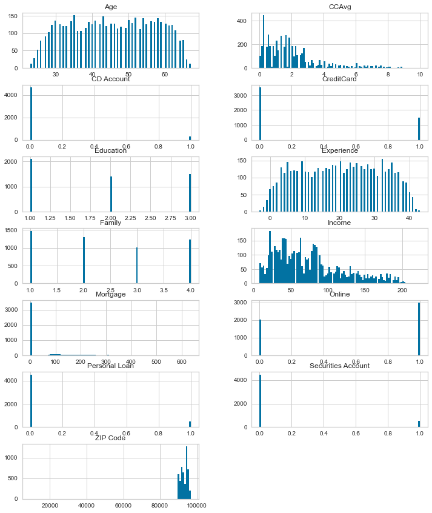

```python
#Univariate and Bivariate
#1st we plot graps for Univariate
columns = list(Bank_df)[1:]
Bank_df[columns].hist(stacked=False, bins=100, figsize=(12,30), layout=(14,2));
```

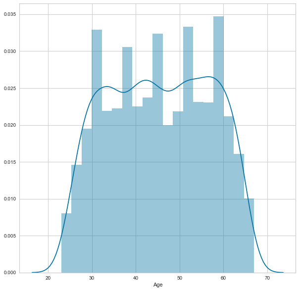

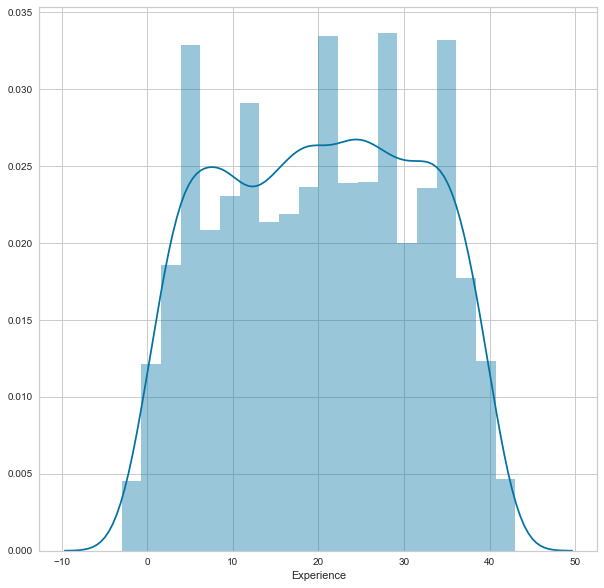

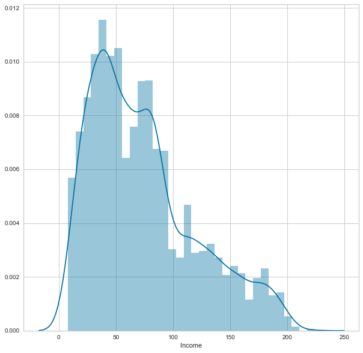

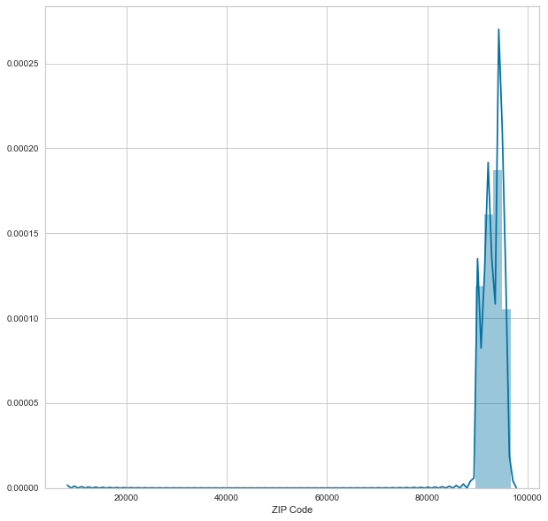

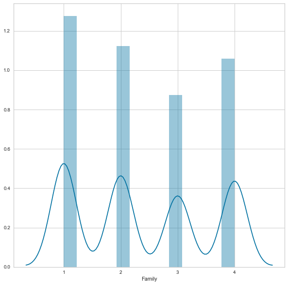

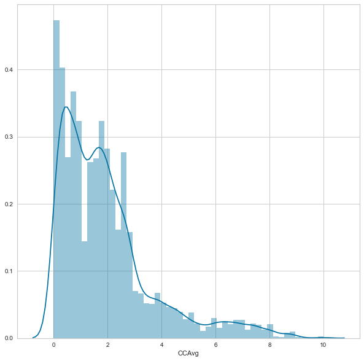

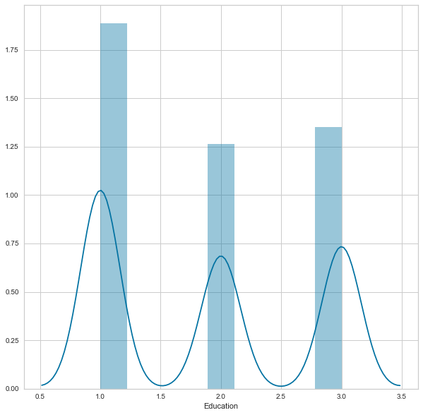

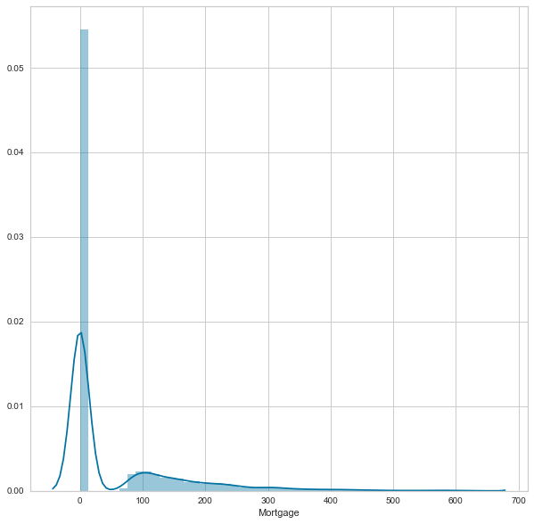

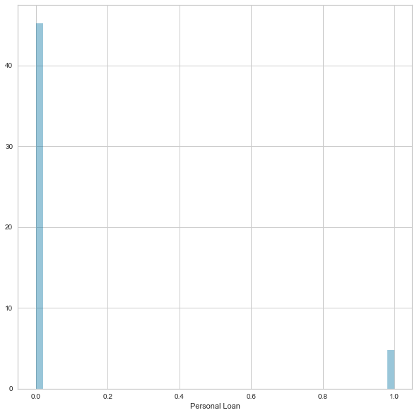

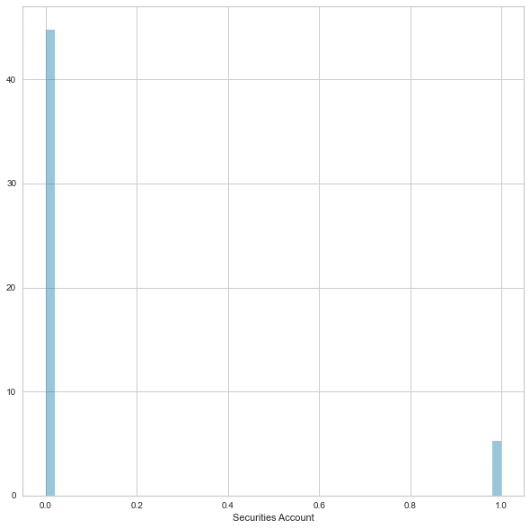

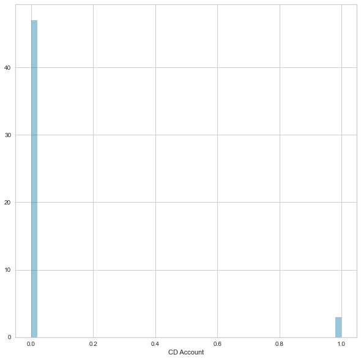

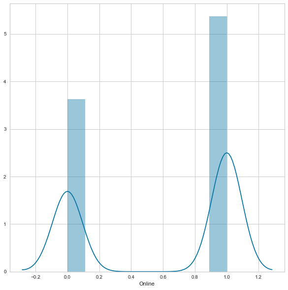

[1 more figures not shown]

```python
for i in columns:
    plt.figure(figsize = (10,10))
    sns.distplot(Bank_df[i])
    plt.show()
```

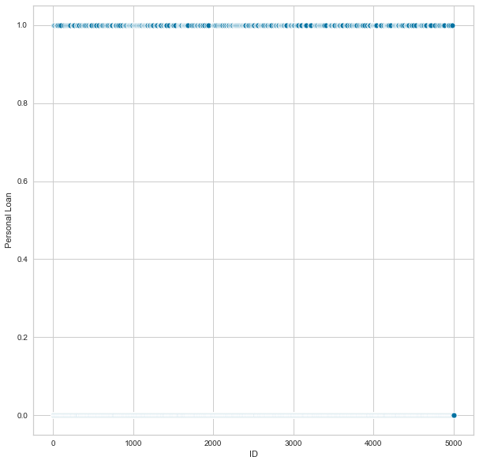

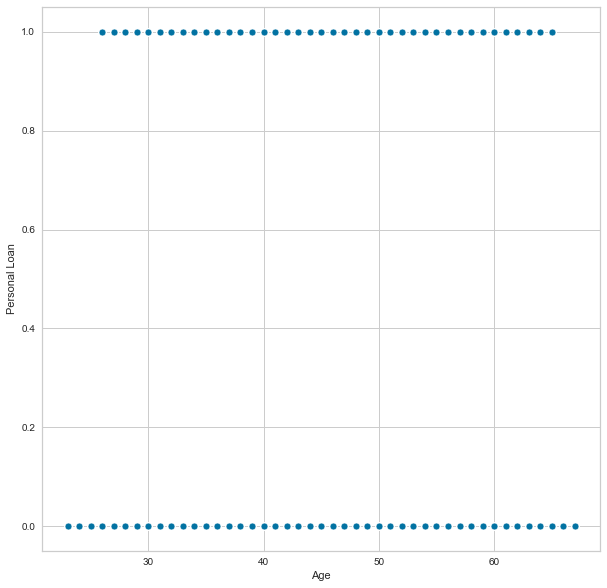

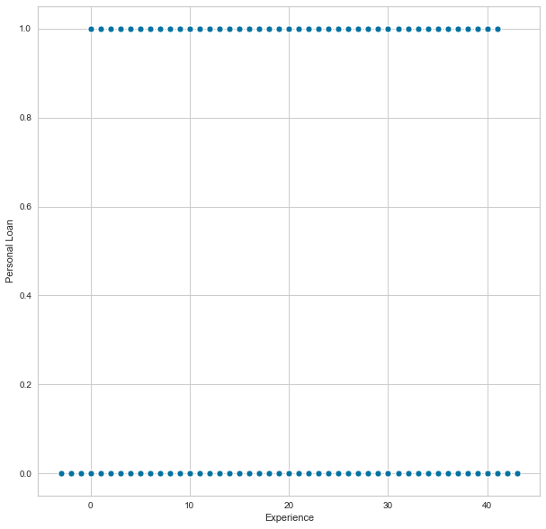

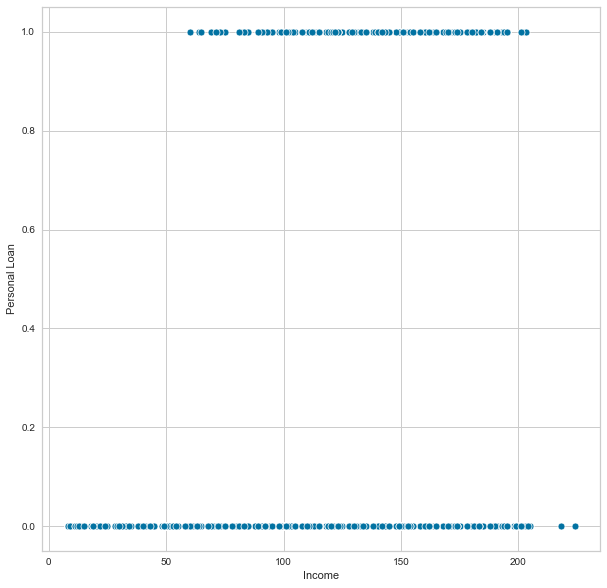

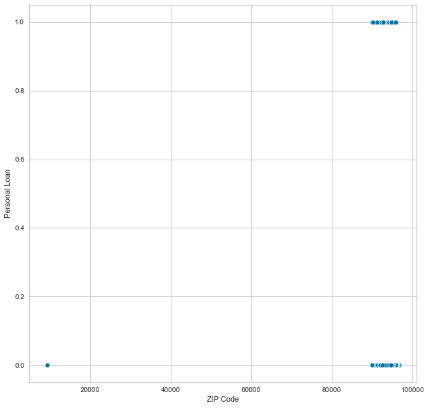

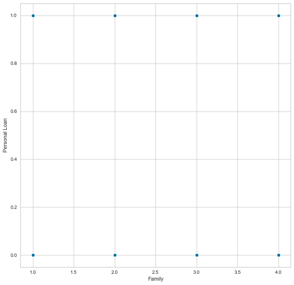

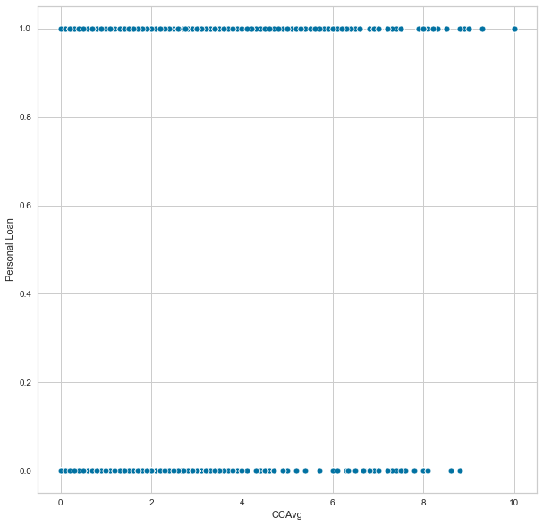

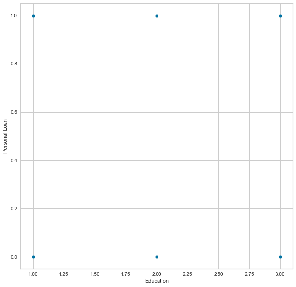

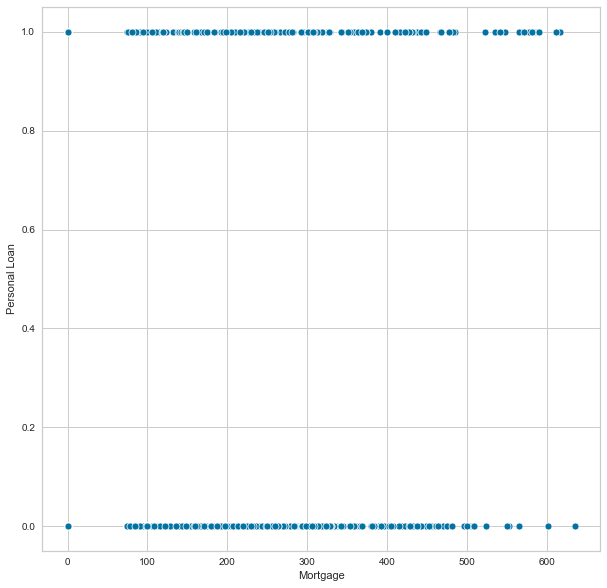

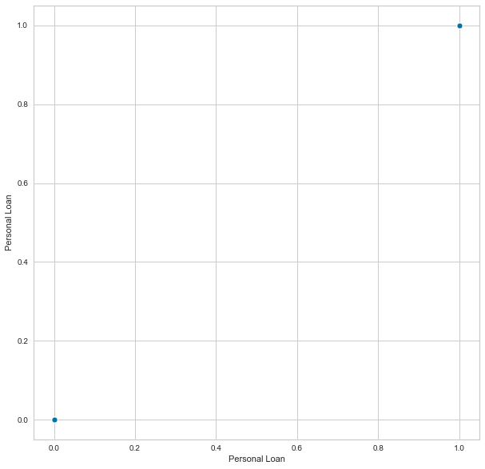

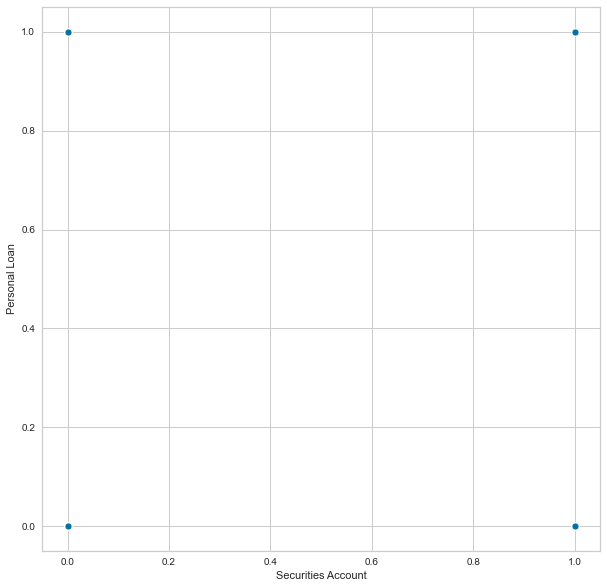

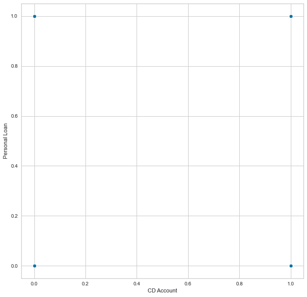

[2 more figures not shown]

```python
#Bivariate
#Bivariate Scatterplot respective personal loan
for i in Bank_df.columns:
    plt.figure(figsize = (10,10))
    sns.scatterplot(x = Bank_df[i], y = Bank_df['Personal Loan']  )
    plt.show()
```

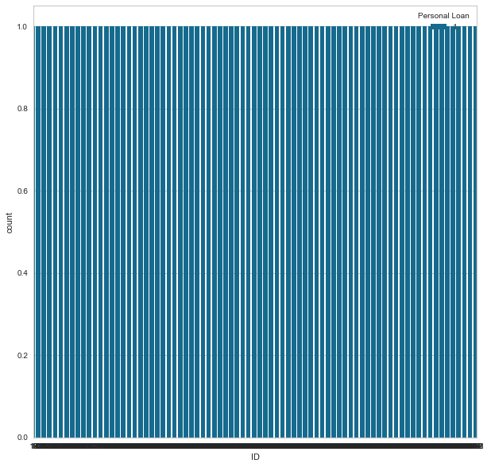

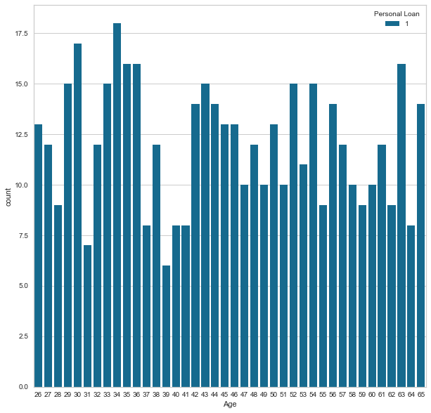

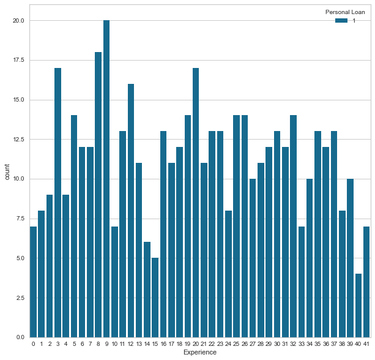

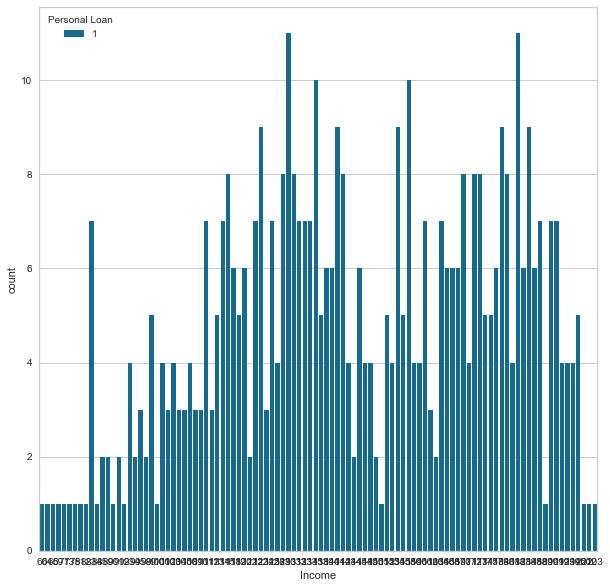

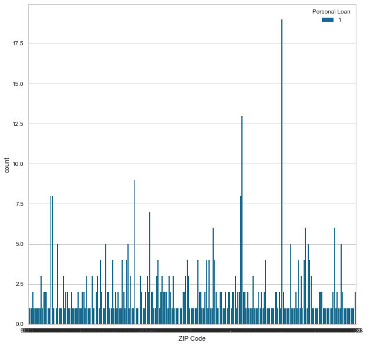

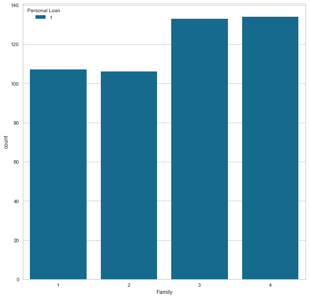

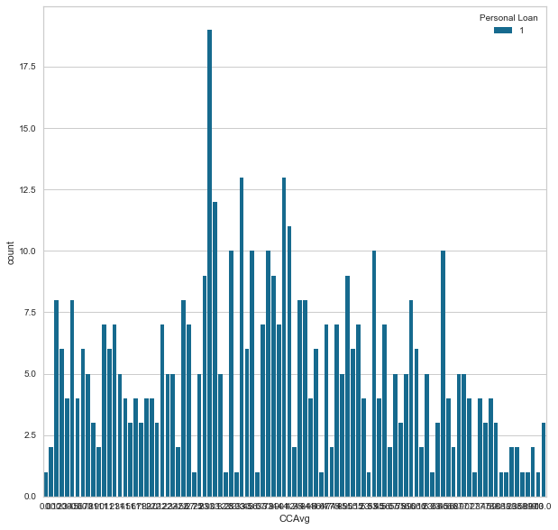

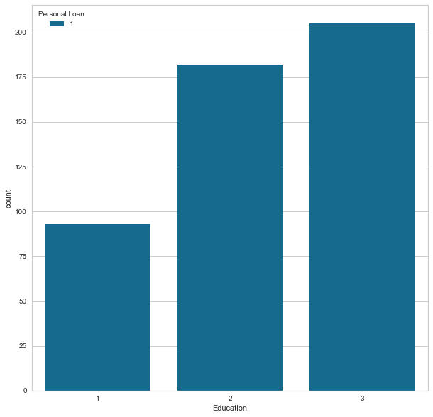

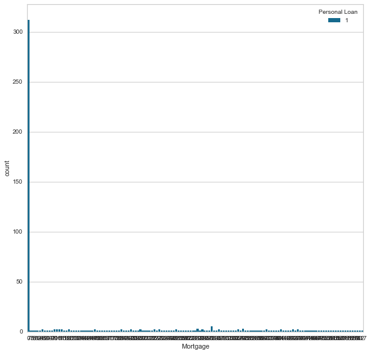

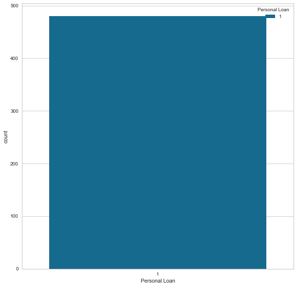

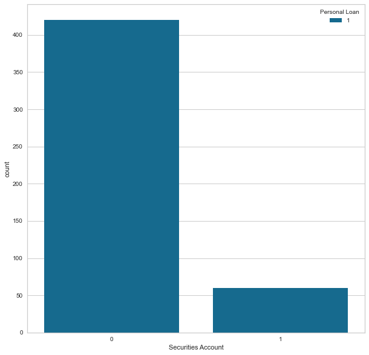

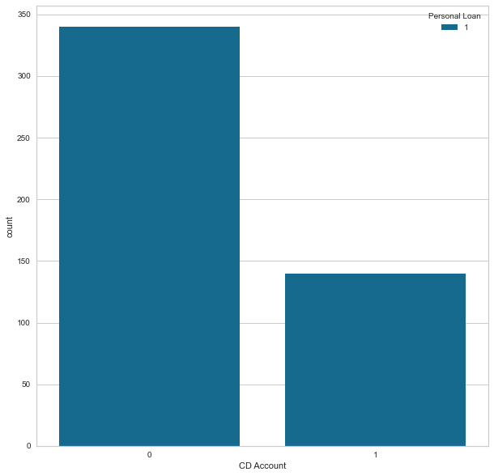

[2 more figures not shown]

```python
#Bivariate countplot respective personal loan on those took loan in earlier campaigns
Bank_df_Y_1= Bank_df [Bank_df['Personal Loan']==1]
for i in Bank_df_Y_1.columns:
    plt.figure(figsize = (10,10))
    sns.countplot(x = Bank_df_Y_1[i],data=Bank_df_Y_1, hue = Bank_df_Y_1['Personal Loan']  )
    plt.show()
```

```python
#Get data model ready
##Model 1: This is going to be 1st Beanch Mark Model
#Step 1: Clean and remove columns thats unlikely alter outcome
#Step 2: separating dependent and independent variables
#Step 3: Using Groupby view relationship (kind of Bivariate Analysis in addition to above graphical presentation)
```

```python
Bank_df.drop(["ID","ZIP Code"],axis=1, inplace=True)
```

```python
Bank_df['Experience'].clip(lower=0, inplace=True) #Experience column has -ve value so replace with 0
```

```python
prop_Y = Bank_df['Personal Loan'].value_counts(normalize=True)*100
print(prop_Y) #just re-verfiy volume
```

```
0   90.40
1    9.60
Name: Personal Loan, dtype: float64
```

```python
Bank_df.groupby(["Personal Loan"]).mean()
```

| Personal Loan | Age | Experience | Income | Family | CCAvg | Education | Mortgage | Securities Account | CD Account | Online | CreditCard |
| --- | --- | --- | --- | --- | --- | --- | --- | --- | --- | --- | --- |
| 0 | 45.37 | 20.15 | 66.24 | 2.37 | 1.73 | 1.84 | 51.79 | 0.10 | 0.04 | 0.60 | 0.29 |
| 1 | 45.07 | 19.84 | 144.75 | 2.61 | 3.91 | 2.23 | 100.85 | 0.12 | 0.29 | 0.61 | 0.30 |

```python
Bank_df.groupby(["Personal Loan"]).median()
```

| Personal Loan | Age | Experience | Income | Family | CCAvg | Education | Mortgage | Securities Account | CD Account | Online | CreditCard |
| --- | --- | --- | --- | --- | --- | --- | --- | --- | --- | --- | --- |
| 0 | 45.00 | 20.00 | 59.00 | 2.00 | 1.40 | 2.00 | 0.00 | 0.00 | 0.00 | 1.00 | 0.00 |
| 1 | 45.00 | 20.00 | 142.50 | 3.00 | 3.80 | 2.00 | 0.00 | 0.00 | 0.00 | 1.00 | 0.00 |

```python
pd.crosstab(Bank_df['Family'],Bank_df['Personal Loan'],normalize='index')
```

| Personal Loan Family | 0 | 1 |
| --- | --- | --- |
| 1 | 0.93 | 0.07 |
| 2 | 0.92 | 0.08 |
| 3 | 0.87 | 0.13 |
| 4 | 0.89 | 0.11 |

```python
X=Bank_df.drop(['Personal Loan','Age'], axis=1)
Y=Bank_df[['Personal Loan']]
```

```python
#Task 3: Split the data into training and test set in the ratio of 70:30 respectively

X_train, X_test, y_train, y_test = train_test_split(X, Y, test_size=0.30 , random_state=1)
```

```python
#Task 4 : Use Logistic Regression model to predict whether the customer will take personal loan or
#not. Print all the metrics related for evaluating the model performance

from sklearn.metrics import confusion_matrix, recall_score, precision_score, f1_score, roc_auc_score,accuracy_score
from sklearn.linear_model import LogisticRegression

logreg = LogisticRegression(random_state=7)
logreg.fit(X_train, y_train)
```

```
LogisticRegression(random_state=7)
```

```python
y_predict = logreg.predict(X_test)
```

```python
## function to get confusion matrix in a proper format
def draw_cm( actual, predicted ):
    cm = confusion_matrix( actual, predicted)
    sns.heatmap(cm, annot=True,  fmt='.2f', xticklabels = [0,1] , yticklabels = [0,1] )
    plt.ylabel('Observed')
    plt.xlabel('Predicted')
    plt.show()
```

```python
z = X_test.copy()
z['Observed'] = y_test
z['Predicted'] = y_predict
#print(z)
#z.query('Observed==1 & Predicted==1 & Family==1') #TP
#z.groupby(["Predicted"]).median()
```

```
Trainig accuracy 0.9468571428571428

Testing accuracy 0.9433333333333334

Confusion Matrix for model 1, Beanch-mark
```

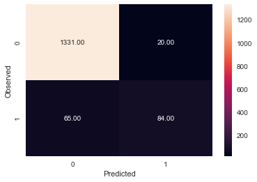

```
None

Recall/Sensitivity: 0.5637583892617449

Precision: 0.8076923076923077



F1 Score: 0.6640316205533597

Roc Auc Score: 0.7744772701305024
```

```python
print("Trainig accuracy",logreg.score(X_train,y_train))
print()
print("Testing accuracy",logreg.score(X_test, y_test))
print()
print('Confusion Matrix for model 1, Beanch-mark')
print(draw_cm(y_test,y_predict))
print()
print("Recall/Sensitivity:",recall_score(y_test,y_predict))
print()
print("Precision:",precision_score(y_test,y_predict))
print()
print()
#print("Specificity:",specificity_score(y_test,y_predict))
print()
print("F1 Score:",f1_score(y_test,y_predict))
print()
print("Roc Auc Score:",roc_auc_score(y_test,y_predict))
```

# Notes: Based on the customers who has higher income,more family members and higher spending would be consider in target for personal loan.

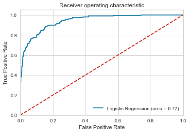

```python
#AUC ROC curve
from sklearn.metrics import roc_auc_score
from sklearn.metrics import roc_curve

logit_roc_auc = roc_auc_score(y_test, logreg.predict(X_test))
fpr, tpr, thresholds = roc_curve(y_test, logreg.predict_proba(X_test)[:,1])
plt.figure()
plt.plot(fpr, tpr, label='Logistic Regression (area = %0.2f)' % logit_roc_auc)
plt.plot([0, 1], [0, 1],'r--')
plt.xlim([0.0, 1.0])
plt.ylim([0.0, 1.05])
plt.xlabel('False Positive Rate')
plt.ylabel('True Positive Rate')
plt.title('Receiver operating characteristic')
plt.legend(loc="lower right")
plt.savefig('Log_ROC')
plt.show()
```

```python
##Model 2: This is going to be addition of Model 1 (Exp2)
Bank_df_2=Bank_df
Bank_df_2.describe().transpose()
```

|  | count | mean | std | min | 25% | 50% | 75% | max |
| --- | --- | --- | --- | --- | --- | --- | --- | --- |
| Age | 5000.00 | 45.34 | 11.46 | 23.00 | 35.00 | 45.00 | 55.00 | 67.00 |
| Experience | 5000.00 | 20.12 | 11.44 | 0.00 | 10.00 | 20.00 | 30.00 | 43.00 |
| Income | 5000.00 | 73.77 | 46.03 | 8.00 | 39.00 | 64.00 | 98.00 | 224.00 |
| Family | 5000.00 | 2.40 | 1.15 | 1.00 | 1.00 | 2.00 | 3.00 | 4.00 |
| CCAvg | 5000.00 | 1.94 | 1.75 | 0.00 | 0.70 | 1.50 | 2.50 | 10.00 |
| Education | 5000.00 | 1.88 | 0.84 | 1.00 | 1.00 | 2.00 | 3.00 | 3.00 |
| Mortgage | 5000.00 | 56.50 | 101.71 | 0.00 | 0.00 | 0.00 | 101.00 | 635.00 |
| Personal Loan | 5000.00 | 0.10 | 0.29 | 0.00 | 0.00 | 0.00 | 0.00 | 1.00 |
| Securities Account | 5000.00 | 0.10 | 0.31 | 0.00 | 0.00 | 0.00 | 0.00 | 1.00 |
| CD Account | 5000.00 | 0.06 | 0.24 | 0.00 | 0.00 | 0.00 | 0.00 | 1.00 |
| Online | 5000.00 | 0.60 | 0.49 | 0.00 | 0.00 | 1.00 | 1.00 | 1.00 |
| CreditCard | 5000.00 | 0.29 | 0.46 | 0.00 | 0.00 | 0.00 | 1.00 | 1.00 |

# Convert X & Y variable to a categorical variables all relevant

Bank_df_2['Personal Loan'] = Bank_df_2['Personal Loan'].astype('category') Bank_df_2['CreditCard'] = Bank_df_2['CreditCard'].astype('category') Bank_df_2['Family'] = Bank_df_2['Family'].astype('category') Bank_df_2['Education'] = Bank_df_2['Education'].astype('category') Bank_df_2['Securities Account'] = Bank_df_2['Securities Account'].astype('category') Bank_df_2['CD Account'] = Bank_df_2['CD Account'].astype('category') Bank_df_2['Online'] = Bank_df_2['Online'].astype('category')

```python
print(logreg.coef_, logreg.intercept_)
```

```
[[-2.39595395e-02  4.25357966e-02  1.24297792e-01  1.19186755e-01
   1.60324490e+00  1.39086357e-04 -7.04650027e-01  5.02140091e+00
  -1.83309644e+00 -1.61828078e+00]] [-9.18130524]
```

```python
X_test
```

|  | Experience | Income | Family | CCAvg | Education | Mortgage | Securities Account | CD Account | Online | CreditCard |
| --- | --- | --- | --- | --- | --- | --- | --- | --- | --- | --- |
| 2764 | 5 | 84 | 1 | 2.90 | 3 | 105 | 0 | 0 | 0 | 1 |
| 4767 | 9 | 45 | 3 | 0.90 | 1 | 101 | 1 | 0 | 0 | 0 |
| 3814 | 9 | 35 | 3 | 1.30 | 1 | 0 | 0 | 0 | 0 | 0 |
| 3499 | 23 | 114 | 1 | 0.30 | 1 | 286 | 0 | 0 | 1 | 0 |
| 2735 | 12 | 70 | 3 | 2.60 | 2 | 165 | 0 | 0 | 1 | 0 |
| ... | ... | ... | ... | ... | ... | ... | ... | ... | ... | ... |
| 4140 | 38 | 32 | 1 | 1.50 | 2 | 0 | 0 | 0 | 0 | 0 |
| 3969 | 11 | 75 | 3 | 2.33 | 2 | 0 | 0 | 0 | 1 | 0 |
| 2535 | 25 | 21 | 2 | 0.70 | 3 | 129 | 0 | 0 | 0 | 0 |
| 1361 | 26 | 38 | 4 | 0.90 | 2 | 0 | 0 | 0 | 1 | 0 |
| 1458 | 25 | 33 | 1 | 1.40 | 3 | 0 | 0 | 0 | 1 | 1 |

1500 rows × 10 columns

```python
X=Bank_df_2.drop(['Personal Loan','Age','Experience','Securities Account','Online','CreditCard'], axis=1) #exclude one more column Experience
Y=Bank_df_2[['Personal Loan']]
```

# Convert categorical vriables to dummy variables

X = pd.get_dummies(X, drop_first=True)

```python
##Split into training and test set
from sklearn.model_selection import train_test_split

X_train, X_test, y_train, y_test = train_test_split(X, Y, test_size=0.30,random_state=7)
```

```python
#list(zip(X, model.feature_importances_))
```

```python
#splitting the data in 70:30 ratio of train to test data
from sklearn.metrics import confusion_matrix, recall_score, precision_score, f1_score, roc_auc_score,accuracy_score
from sklearn.linear_model import LogisticRegression

logreg = LogisticRegression(random_state=7)
logreg.fit(X_train, y_train)

y_predict = logreg.predict(X_test)
```

```
Trainig accuracy 0.9437142857142857

Testing accuracy 0.9513333333333334

Confusion Matrix for model 2
```

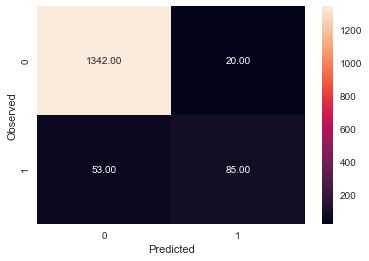

```
None

Recall: 0.6159420289855072

Precision: 0.8095238095238095

F1 Score: 0.6995884773662552

Roc Auc Score: 0.8006288705867332
```

```python
print("Trainig accuracy",logreg.score(X_train,y_train))
print()
print("Testing accuracy",logreg.score(X_test, y_test))
print()
print('Confusion Matrix for model 2')
print(draw_cm(y_test,y_predict))
print()
print("Recall:",recall_score(y_test,y_predict))
print()
print("Precision:",precision_score(y_test,y_predict))
print()
print("F1 Score:",f1_score(y_test,y_predict))
print()
print("Roc Auc Score:",roc_auc_score(y_test,y_predict))
```

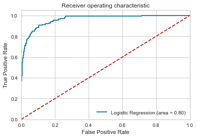

```python
#AUC ROC curve
from sklearn.metrics import roc_auc_score
from sklearn.metrics import roc_curve

logit_roc_auc = roc_auc_score(y_test, logreg.predict(X_test))
fpr, tpr, thresholds = roc_curve(y_test, logreg.predict_proba(X_test)[:,1])
plt.figure()
plt.plot(fpr, tpr, label='Logistic Regression (area = %0.2f)' % logit_roc_auc)
plt.plot([0, 1], [0, 1],'r--')
plt.xlim([0.0, 1.0])
plt.ylim([0.0, 1.05])
plt.xlabel('False Positive Rate')
plt.ylabel('True Positive Rate')
plt.title('Receiver operating characteristic')
plt.legend(loc="lower right")
plt.savefig('Log_ROC')
plt.show()
```

- Note : Model 2 tried with both options with or without converting binary to categorical variables using dummy variables. Also in Model 2, the count of FN come down and increase TP count and increase AUC.

```python
#Task 5 : Check different parameters of Logistic Regression and give your reasoning whether the
#model performance is affected due to it or not?

# Running a loop to check different values of 'solver'
# all solver can be used with l2, only 'liblinear' and 'saga' works with both 'l1' and 'l2'

train_score=[]
test_score=[]
solver = ['newton-cg','lbfgs','liblinear','sag','saga']
for i in solver:
    model = LogisticRegression(random_state=42,penalty='l2', C = 0.01,solver=i)  # changing values of solver
    model.fit(X_train, y_train)
    y_predict = model.predict(X_test)
    train_score.append(round(model.score(X_train, y_train),3))
    test_score.append(round(model.score(X_test, y_test),3))

print(solver)
print()
print(train_score)
print()
print(test_score)
```

```
['newton-cg', 'lbfgs', 'liblinear', 'sag', 'saga']

[0.935, 0.935, 0.898, 0.902, 0.902]

[0.946, 0.946, 0.906, 0.908, 0.908]
```

```python
train_score=[]
test_score=[]
solver = ['liblinear','saga']   # changing values of solver which works with 'l1'
for i in solver:
    model = LogisticRegression(random_state=42,penalty='l1', C = 0.50,solver=i)  #changed penalty to 'l1'
    model.fit(X_train, y_train)
    y_predict = model.predict(X_test)
    train_score.append(round(model.score(X_train, y_train),3))
    test_score.append(round(model.score(X_test, y_test),3))

print(solver)
print()
print(train_score)
print()
print(test_score)
```

```
['liblinear', 'saga']

[0.944, 0.902]

[0.951, 0.908]
```

```python
# Running a loop to check different values of 'C'

train_score=[]
test_score=[]
C = [0.01,0.1,0.25,0.5,0.75,1]
for i in C:
    model = LogisticRegression(random_state=42,penalty='l2', solver='newton-cg',class_weight='balanced', C=i)  # changing values of C
    model.fit(X_train, y_train)
    y_predict = model.predict(X_test)
    train_score.append(round(model.score(X_train,y_train),3)) # appending training accuracy in a blank list for every run of the loop
    test_score.append(round(model.score(X_test, y_test),3))   # appending testing accuracy in a blank list for every run of the loop

print(C)
print()
print(train_score)
print()
print(test_score)
```

```
[0.01, 0.1, 0.25, 0.5, 0.75, 1]

[0.886, 0.893, 0.893, 0.891, 0.891, 0.891]

[0.878, 0.895, 0.893, 0.893, 0.892, 0.893]
```

```
Trainig accuracy 0.8905714285714286

Testing accuracy 0.8933333333333333

Confusion Matrix for model 3, final
```

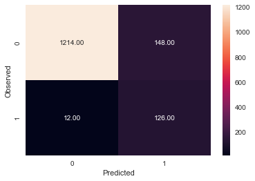

```
None
Recall: 0.9130434782608695


Precision: 0.45985401459854014

F1 Score: 0.6116504854368932

Roc Auc Score: 0.9021898742258827
```

```python
model = LogisticRegression(random_state=42,penalty='l1',solver='liblinear',class_weight='balanced',C=0.25) # changing class weight to balanced

model.fit(X_train, y_train)

y_predict = model.predict(X_test)

print("Trainig accuracy",model.score(X_train,y_train))
print()
print("Testing accuracy",model.score(X_test, y_test))
print()
print('Confusion Matrix for model 3, final')
print(draw_cm(y_test,y_predict))
print("Recall:",recall_score(y_test,y_predict))
print()
print()
print("Precision:",precision_score(y_test,y_predict))
print()
print("F1 Score:",f1_score(y_test,y_predict))
print()
print("Roc Auc Score:",roc_auc_score(y_test,y_predict))
```

```
Trainig accuracy 0.8928571428571429

Testing accuracy 0.8933333333333333

Confusion Matrix for model 4, final
```

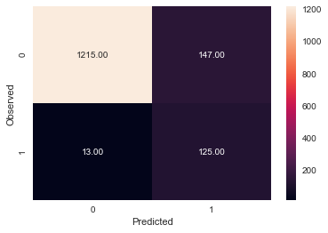

```
None
Recall: 0.9057971014492754


Precision: 0.45955882352941174

F1 Score: 0.6097560975609757

Roc Auc Score: 0.8989337930153866
```

```python
model_l2 = LogisticRegression(random_state=42,penalty='l2',solver='newton-cg',class_weight='balanced',C=0.25) # changing class weight to balanced

model_l2.fit(X_train, y_train)

y_predict = model_l2.predict(X_test)

print("Trainig accuracy",model_l2.score(X_train,y_train))
print()
print("Testing accuracy",model_l2.score(X_test, y_test))
print()
print('Confusion Matrix for model 4, final')
print(draw_cm(y_test,y_predict))
print("Recall:",recall_score(y_test,y_predict))
print()
print()
print("Precision:",precision_score(y_test,y_predict))
print()
print("F1 Score:",f1_score(y_test,y_predict))
print()
print("Roc Auc Score:",roc_auc_score(y_test,y_predict))
```

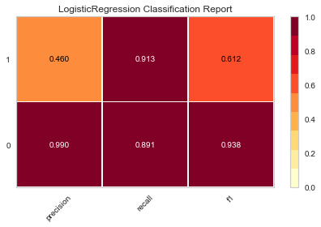

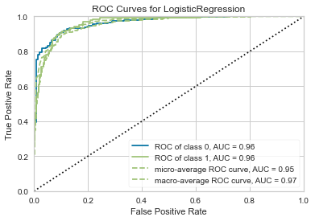

```python
# Additional

from yellowbrick.classifier import ClassificationReport, ROCAUC
# Visualize model performance with yellowbrick library
viz = ClassificationReport(model)
viz.fit(X_train, y_train)
viz.score(X_test, y_test)
viz.show()

roc = ROCAUC(model)
roc.fit(X_train, y_train)
roc.score(X_test, y_test)
roc.show()
```

```python
#Build the logistic regression model, NOT SURE THIS IS NEEDED HOWEVER ADDED FOR ADDITIONAL CHECK. PLEASE IGNORE
```

```python
import statsmodels.api as sm

logit = sm.Logit(y_train, sm.add_constant(X_train))
lg = logit.fit()
from scipy import stats
stats.chisqprob = lambda chisq, df: stats.chi2.sf(chisq, df)
print(lg.summary())
```

```
Optimization terminated successfully.
         Current function value: 0.138844
         Iterations 9
                           Logit Regression Results
==============================================================================
Dep. Variable:          Personal Loan   No. Observations:                 3500
Model:                          Logit   Df Residuals:                     3493
Method:                           MLE   Df Model:                            6
Date:                Fri, 18 Sep 2020   Pseudo R-squ.:                  0.5662
Time:                        01:12:23   Log-Likelihood:                -485.95
converged:                       True   LL-Null:                       -1120.1
Covariance Type:            nonrobust   LLR p-value:                7.844e-271
==============================================================================
                 coef    std err          z      P>|z|      [0.025      0.975]
------------------------------------------------------------------------------
const        -13.5552      0.638    -21.240      0.000     -14.806     -12.304
Income         0.0511      0.003     17.665      0.000       0.045       0.057
Family         0.7600      0.086      8.842      0.000       0.592       0.928
CCAvg          0.1477      0.046      3.228      0.001       0.058       0.237
Education      1.6268      0.125     12.966      0.000       1.381       1.873
Mortgage       0.0008      0.001      1.333      0.183      -0.000       0.002
CD Account     2.3801      0.264      9.000      0.000       1.862       2.898
==============================================================================
```

```python
lgcoef = pd.DataFrame(lg.params, columns=['coef'])
lgcoef.loc[:, "Odds_ratio"] = np.exp(lgcoef.coef)
lgcoef['probability'] = lgcoef['Odds_ratio']/(1+lgcoef['Odds_ratio'])
lgcoef['pval']=lg.pvalues
pd.options.display.float_format = '{:.2f}'.format
lgcoef = lgcoef.sort_values(by="Odds_ratio", ascending=False)
pval_filter = lgcoef['pval']<=0.1
lgcoef[pval_filter]
```

|  | coef | Odds_ratio | probability | pval |
| --- | --- | --- | --- | --- |
| CD Account | 2.38 | 10.81 | 0.92 | 0.00 |
| Education | 1.63 | 5.09 | 0.84 | 0.00 |
| Family | 0.76 | 2.14 | 0.68 | 0.00 |
| CCAvg | 0.15 | 1.16 | 0.54 | 0.00 |
| Income | 0.05 | 1.05 | 0.51 | 0.00 |
| const | -13.56 | 0.00 | 0.00 | 0.00 |

```python
#Task 6 : Give Business understanding of your model?
#1.The dataset is an imbalance in the data given that we need to treat it.
#2.No major difference in case of Experience w.r.t. target variable, excluded in Model 2.
#3.Conversion of X & Y variables to a categorical variable wont see major difference.
#4.Model 2 tried with both options with or without converting binary to categorical variables using dummy variables. Also, in Model 2, the count of FN come down and increase TP count and increase AUC
#5.Checking various parameteres of Logistic Regression and trying various solver model performance affected, we can see increase in Recall and reduce Precision.
#6.At the end, Increase in Recall/FP that means non prospective customer will be convert to propsective customers who take personal loans.
```